# CPM-PERT model

28 februar 2017

## Predstavitev problema

- Podan imamo projekt, ki je sestavljen iz množice *n* opravil. Za vsako opravilo *o* imamo podano trajanje, pa tudi množico drugih opravil, ki jih moramo opraviti pred začetkom opravila *o*. Izračunati moramo čas trajanja celotnega projekta.
- Projekt si lahko predstavljamo kot usmerjen graf, kjer so opravila vozlišča, povezava od vozlišča *i* do *j* pa pomeni, da je opravilo *i* pogoj za opravilo *j*. Dodamo še začetno in končno vozlišče. Iz začetnega vozlišča gredo povezave v vsa vozlišča, ki nimajo drugih vstopnih povezav, v končega pa gredo povezave iz vseh vozlišč, ki nimajo drugih izstopnih povezav.

## Vhodni podatki

- Vektor opravil: vektor števil od 1 do *n*, če imamo *n* opravil
- Seznam predhodnikov: seznam vektorjev, kjer vektor na položaju *i* predstavlja množico opravil, ki so pogoj za opravilo *i*. Če opravilo *i* nima pogojev, potem potem je na *i*-tem mestu vektor, ki vsebuje 0.
- Vektor časov: vektor pozitivnih števil, kjer število na *i*-tem mestu predstavlja trajanje opravila *i*.

## Matrika sosednosti

Graf lahko zapišemo kot matriko sosednosti. To je matrika sestavljena iz 0 in 1, kjer 1-ka na mestu [*i*,*j*] pove, da imamo povezavo, ki gre iz vozlišča *i* v *j*.

V prvem delu najinega programa sestaviva matriko sosednosti:

```r
Adj<-function(Opr,Pred)
  z<-length(Opr)+1
  NO<-c(0, Opr,z)
  A<-matrika velikosti (z+1)*(z+1)
  O<-Opr
  for i in Opr:
    p<-Pred[i]
    for j in p:
      A[j+1,i+1]<-1
      O[!O %in% p]
```

## Matrika sosednosti

```r
for i,j od 1 do z+1:
  if is.na(A[i,j])
      A[i,j]<-0

for i in 1:z :
  if sum(A[i,])==0:
    A[i,z+1]<-1

return(A)
```

## Topološko urejanje

- Ko imamo graf predstavljen v obliki matrike, moramo določiti vrstni red opravljanja opravil. Pri tem si pomagamo z algoritmom za topološko urejanje.

```r
top.sort<-function(Opr, Pred)
  adj<-Adj(Opr,Pred)
  z<-length(Opr)+1
  NO<-c(1, Opr+1,z+1)
  for v in NO:
    st[v]<-sum(adj[,v])
  for v in NO:
    if st[v]==0:
      Q<-c(Q,v)
```

## Topološko urejanje

```r
j<-0
while j<(length(Pred)+2)
  for u in Q
    remove<-c(u)
    Q<-Q[!Q %in% remove]
    top.ured[u]<-j
    j<-j+1
    s<-adj[u,]
    for v in 1:length(s):
      if s[v]==1:
        st[v]<-st[v]-1
        if(st[v]==0){
          Q<-c(Q,v)
return(top.ured)
```

## Topološko urejanje

- Funkcija za topološko urejanje nam vrne vektor zaporednih številk opravljanja (če imamo na *i*-tem mestu številko *j*, to pomeni da se bo *i* opravljal *j*-ti po vrsti). Bolje je, če imamo vektor, kjer si opravila sledijo v istem zaporedju kot se bodo opravljala. Zato uporabimo naslednjo funkcijo:

```r
vrstni.red<-function(sez)
  j<-0
  zaporedje<-c()
  while j<length(sez)
    for i in 1:length(sez)
      if(sez[i]==j)
        zaporedje[j]<-i-1
        j<-j+1
  return(zaporedje)
```

## Trajanje

- Ko enkrat imamo topološko urejanje, moramo le še izračunati čas trajanja projekta. To naredimo s funkcijo trajanje:

```r
trajanje<-function(Opr,Pred,Cas)
  vr<-vrstni.red(top.sort(Opr,Pred))
  cas[vr[1]]<-0
  for i in 2:(length(vr)-1)
    c.pred <- c(0, sapply(Pred[[vr[i]]], function(j) cas[j]+Cas[j]))
    cas[vr[i]]<-max(c.pred)

  a<-Adj(Opr,Pred)[,length(vr)+1]
  for i in 1:length(a):
    if a[i]==1:
      predh<-c(predh,(i-1))
  for j in predh:
    c1<-c(c1,cas[j]+Cas[j])
  konec<-max(c1)
  return(konec)
```

## Enakomerno zvezna porazdelitev

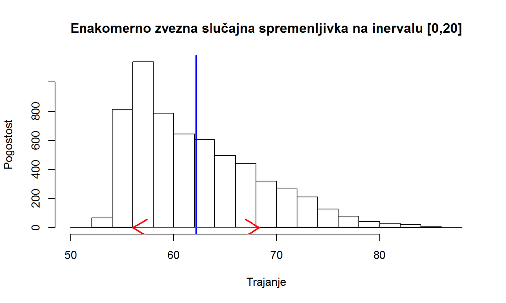

## Enakomerno zvezna porazdelitev

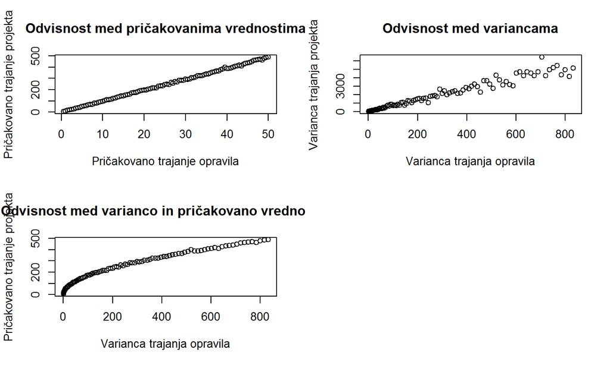

## Okrnjena normalna porazdelitev

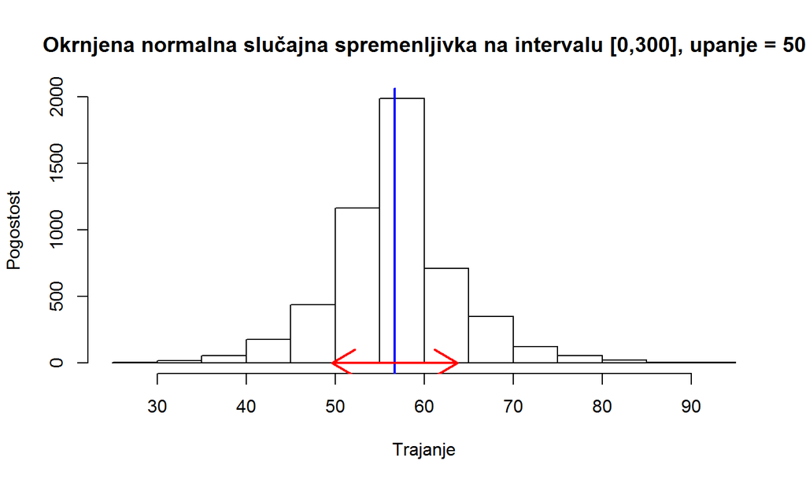

## Okrnjena normalna porazdelitev

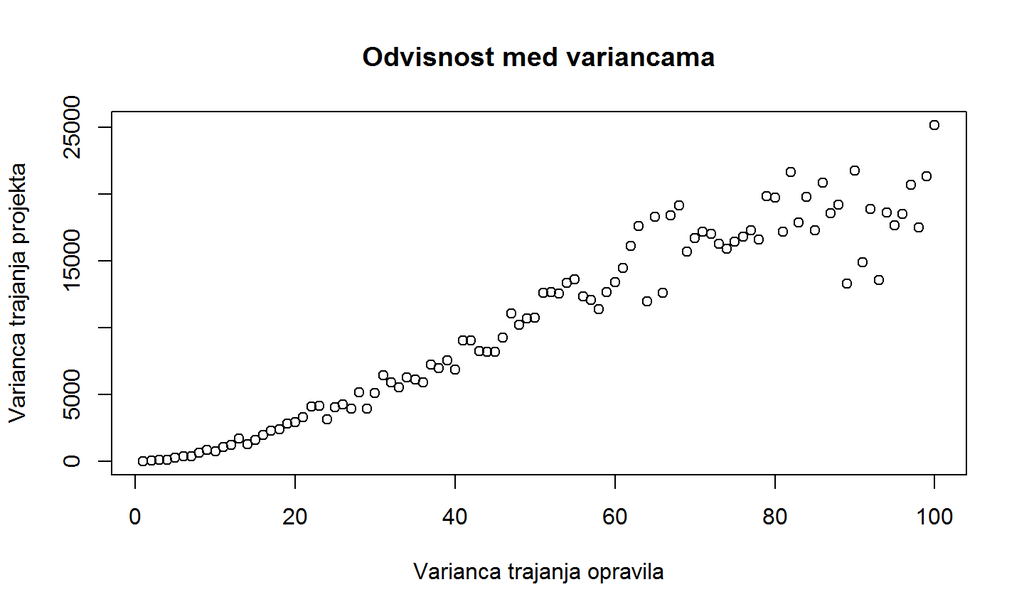

## Okrnjena normalna porazdelitev

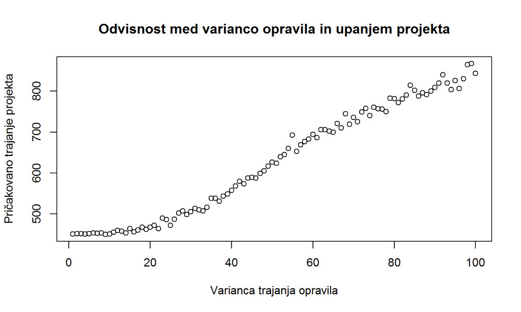

## Eksponentna porazdelitev

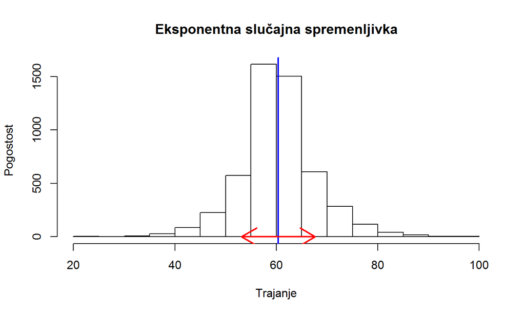

## Eksponentna porazdelitev

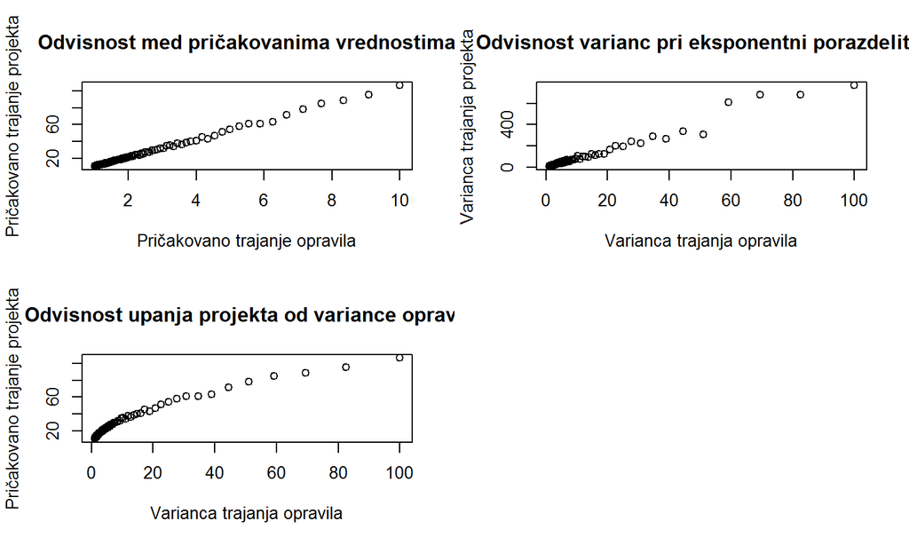

## Porazdelitev Hi-kvadrat

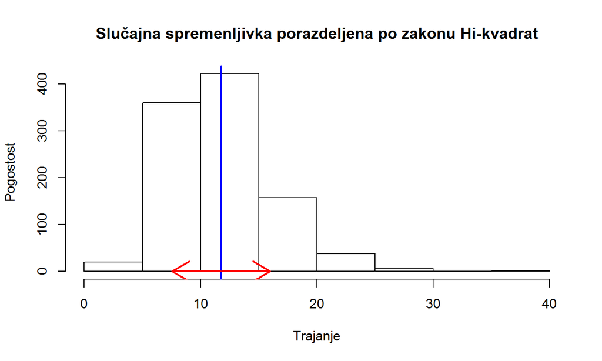

## Porazdelitev Hi-kvadrat

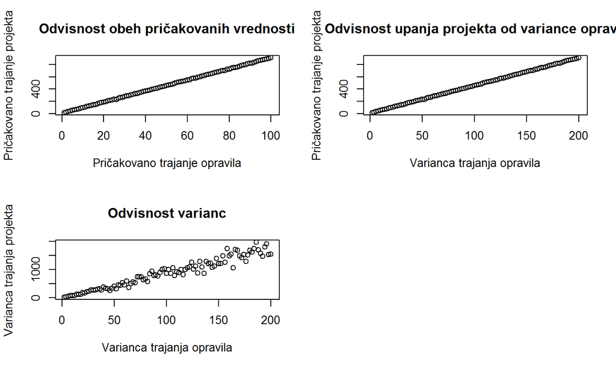

## Porazdelitev Gama

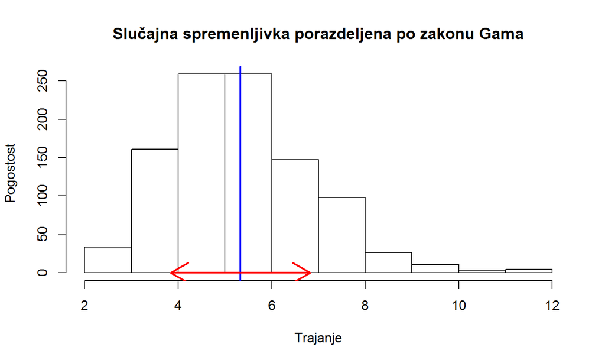

## Porazdelitev Gama

- Spreminjamo parameter oblike

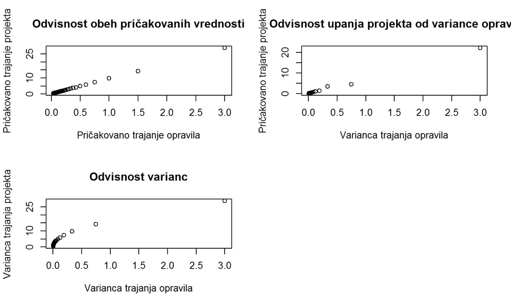

## Simulacija z različnimi parametri

- imamo determinističen vektor časov trajanja opravil
- definiramo funkcijo, ki danemu vektorju priredi slučajni vektor enake dolžine
- parametre porazdelitvene funkcije izberemo tako, da je matematično upanje enako determinističnemu času

## Vhodni podatki

Za vse nadaljne simulacije uporabimo enake vektorje opravil, časov trajanja opravil in predhodnikov:

```r
Opr<-(1:18)
Pred<-list(c(0),c(1),c(2),c(3),c(4,17),c(5),c(6),
           c(6),c(2,10),c(1),c(10), c(11),c(12,17),
           c(13),c(11),c(15,3),c(9,15,16),c(5,13))
Cas<-c(5,3,4,9,12,3,1,7,5,1,3,6,5,3,4,9,12,3)
```

## Premaknjena normalna porazdelitev

```r
simul1 <- function(cas, sd, p) {
        sluc <- vector(length = length(cas))
        i <- 1
        for(c in cas){
                sluc[i] <- rtruncnorm(1, c * p, mean = c, sd = sd)
                i <- i+1
        }
        return(sluc)
}
```

## Premaknjena normalna porazdelitev

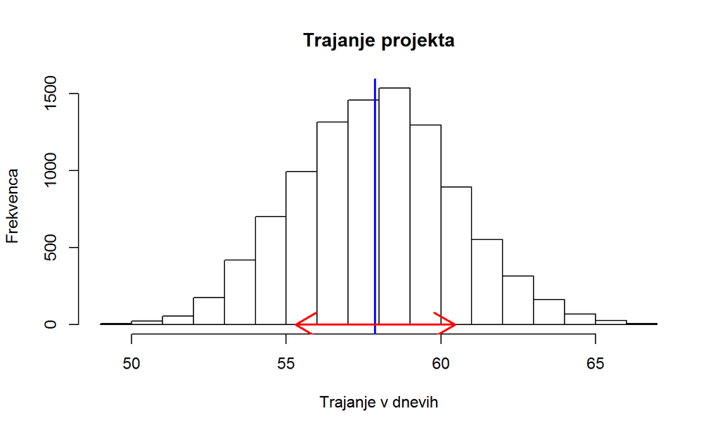

## Premaknjena normalna porazdelitev

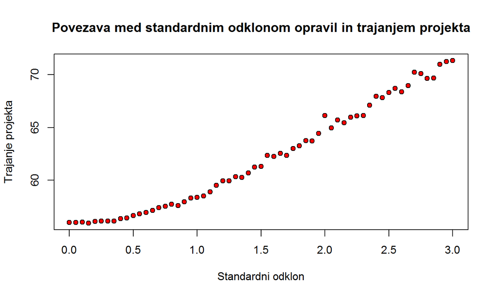

## Enakomerno zvezna porazdelitev

```r
simul2 <- function(cas, m) {
        if(m>2 | m < 0) {return(FALSE)}
        sluc <- vector(length = length(cas))
        n <- max(m, 2-m)
        m <- min(m, 2-m)
        i <- 1
        for(c in cas){
                sluc[i] <- runif(1, min = m*c, max = n * c)
                i <- i+1
        }
        return(sluc)
}
```

## Enakomerno zvezna porazdelitev

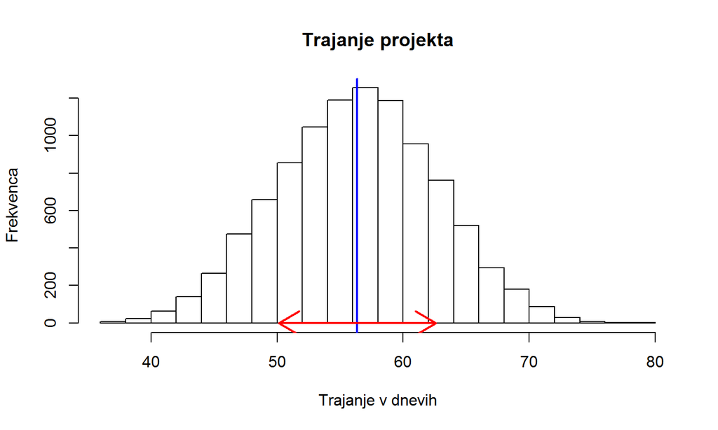

## Enakomerno zvezna porazdelitev

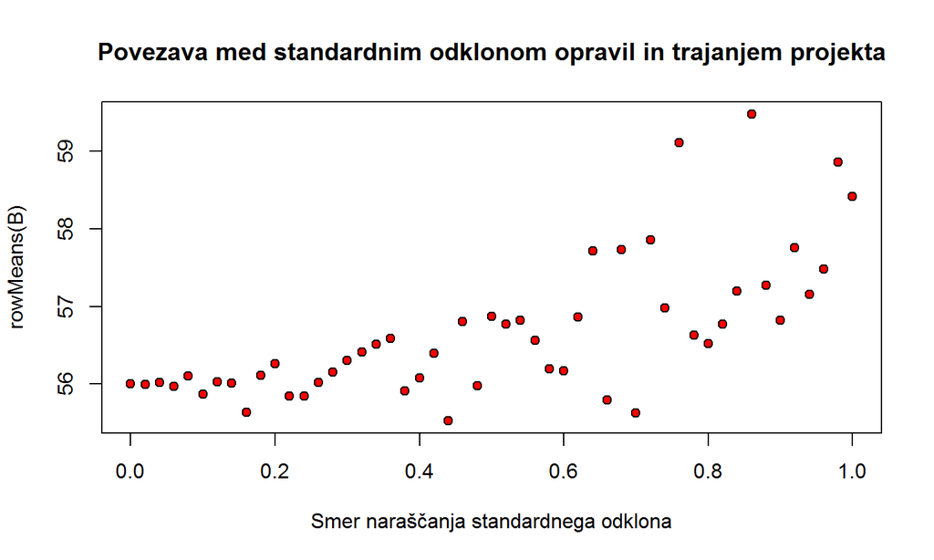

## Enakomerno zvezna porazdelitev 2

```r
ip <- c()
for(a in 1:(length(Opr)-1)) {
        for(b in 1:length(Pred)){
                if(a %in% Pred[[b]] && !(a %in% ip)) {ip <- c(ip, a)}
        }
}

simul21 <- function(cas, m) {
        if(m>2 | m < 0) {return(FALSE)}
        sluc <- vector(length = length(cas))
        n <- max(m, 2-m)
        m <- min(m, 2-m)
        i <- 1
        for(c in cas){
                sluc[i] <- if(i %in% ip) {ceiling(runif(1, min = m*c, max = n * c))}else{
                        runif(1, min = m*c, max = n * c)}
                i <- i+1
        }
        return(sluc)
}
```

## Enakomerno zvezna porazdelitev 2

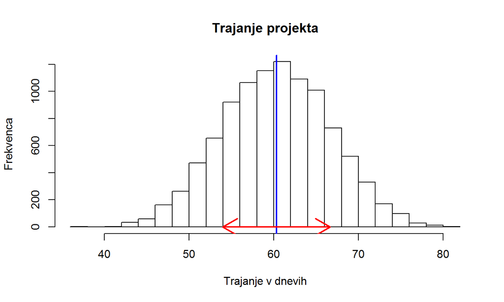

## Enakomerno zvezna porazdelitev 2

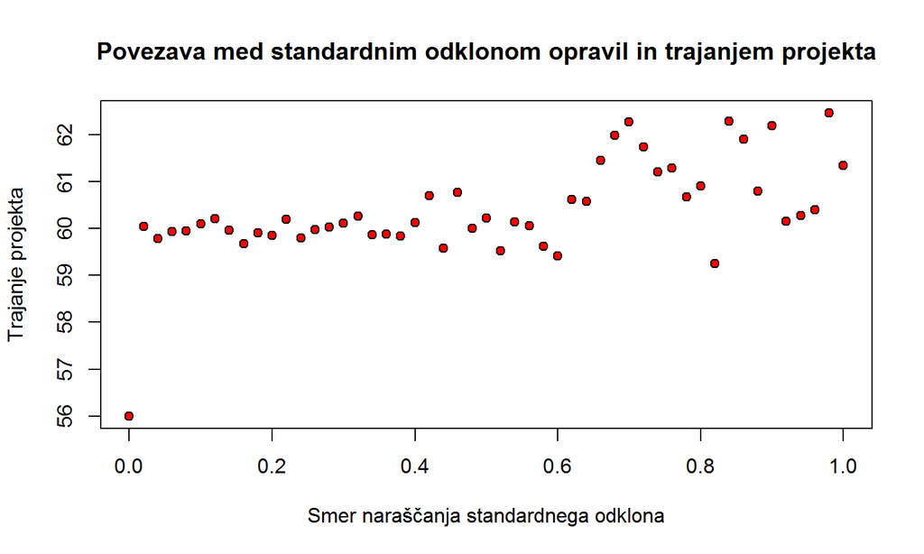

## Binomska porazdelitev

```r
simul3 <- function(cas, n) {
        sluc <- vector(length = length(cas))
        i <- 1
        for(c in cas){
                p <- c / n
                sluc[i] <- max(rbinom(1, n, p), round(0.8*c))
                i <- i+1
        }
        return(sluc)
}
```

## Binomska porazdelitev

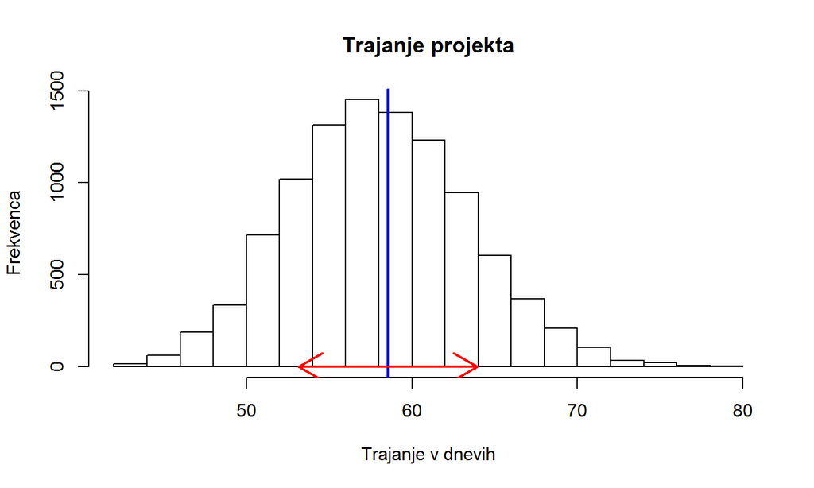